# Airline Passenger Satisfaction

### Categorical Data

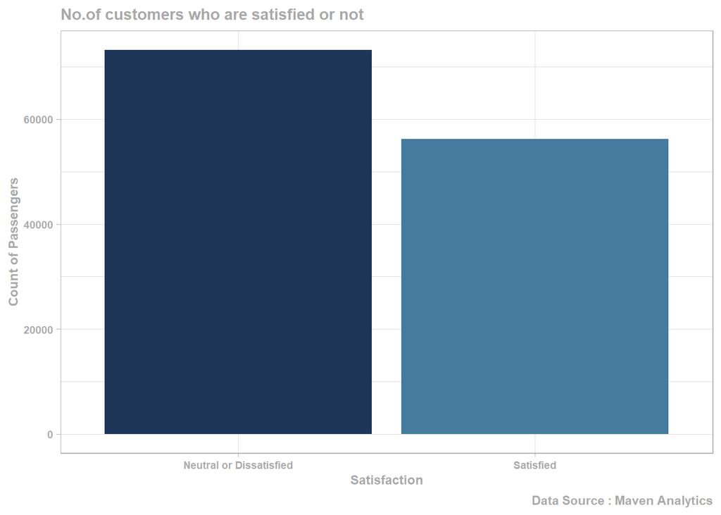

```r
passenger_df %>%
  ggplot(aes(satisfaction, fill = satisfaction)) +
  geom_bar(show.legend = FALSE) +
  theme_light() +
  theme(axis.title.x = element_text(face = "bold",size = 9, color = "darkgrey"),
        axis.text.x = element_text(face = "bold", size = 7, color = "darkgrey"),
        axis.title.y = element_text(face = "bold",size = 9, color = "darkgrey"),
        axis.text.y = element_text(face = "bold", size = 7, color = "darkgrey"),
        plot.title = element_text(color = "darkgrey", face = "bold", size = 11),
        plot.subtitle = element_text(color = "darkgrey", face = "bold", size = 9),
        plot.caption = element_text(color = "darkgrey", face = "bold")) +
  labs(x = "Satisfaction",
       y = "Count of Passengers",
       title = "No.of customers who are satisfied or not",
       caption = "Data Source : Maven Analytics") +
  scale_fill_manual(values = c("#1d3557", "#457b9d"))
```

**57% customers are dis-satisfied over-all.**

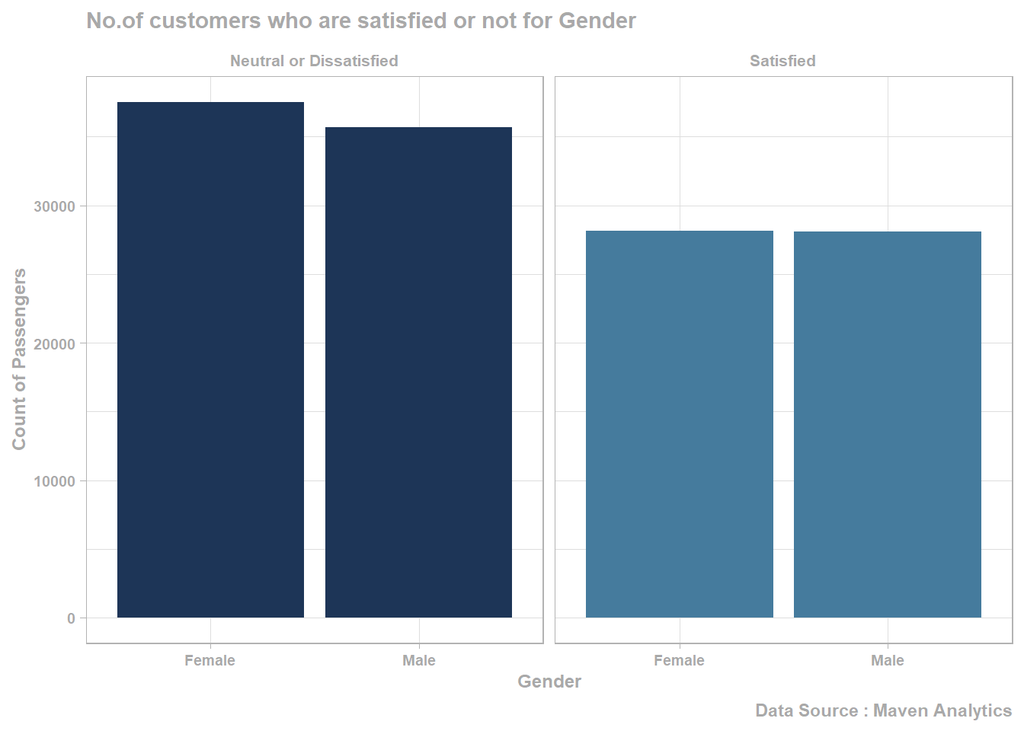

```r
passenger_df %>%
  ggplot(aes(gender, fill = satisfaction)) +
  geom_bar(show.legend = FALSE) +
  scale_fill_manual(values = c("#1d3557", "#457b9d")) +
  theme_light() +
  theme(axis.title.x = element_text(face = "bold",size = 9, color = "darkgrey"),
        axis.text.x = element_text(face = "bold", size = 7, color = "darkgrey"),
        axis.title.y = element_text(face = "bold",size = 9, color = "darkgrey"),
        axis.text.y = element_text(face = "bold", size = 7, color = "darkgrey"),
        plot.title = element_text(color = "darkgrey", face = "bold", size = 11),
        plot.caption = element_text(color = "darkgrey", face = "bold"),
        strip.text.x = element_text(face = "bold", size = 8, color = "darkgrey"),
        strip.background = element_rect(fill = "white")) +
  facet_wrap(vars(satisfaction)) +
  labs(x = "Gender",
       y = "Count of Passengers",
       title = "No.of customers who are satisfied or not for Gender",
       caption = "Data Source : Maven Analytics")
```

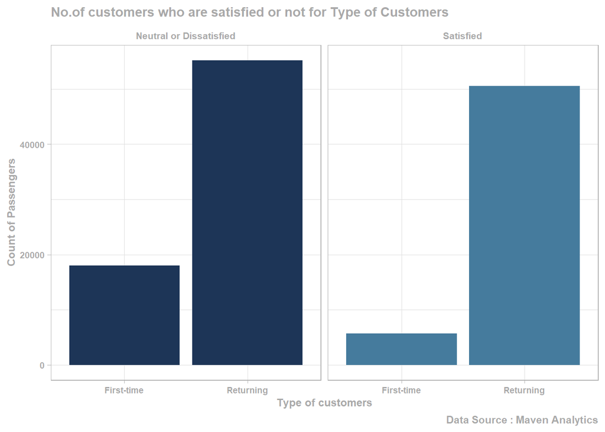

```r
passenger_df %>%
  ggplot(aes(customer_type, fill = satisfaction)) +
  geom_bar(show.legend = FALSE) +
  scale_fill_manual(values = c("#1d3557", "#457b9d")) +
  theme_light() +
  theme(axis.title.x = element_text(face = "bold",size = 9, color = "darkgrey"),
        axis.text.x = element_text(face = "bold", size = 7, color = "darkgrey"),
        axis.title.y = element_text(face = "bold",size = 9, color = "darkgrey"),
        axis.text.y = element_text(face = "bold", size = 7, color = "darkgrey"),
        plot.title = element_text(color = "darkgrey", face = "bold", size = 11),
        plot.caption = element_text(color = "darkgrey", face = "bold"),
        strip.text.x = element_text(face = "bold", size = 8, color = "darkgrey"),
        strip.background = element_rect(fill = "white")) +
  facet_wrap(vars(satisfaction)) +
  labs(x = "Type of customers",
       y = "Count of Passengers",
       title = "No.of customers who are satisfied or not for Type of Customers",
       caption = "Data Source : Maven Analytics")
```

First-Time customers are 18% of the total but 76% are dis-satisfied.  
Returning are more in numbers and 52% are dis-satisfied.

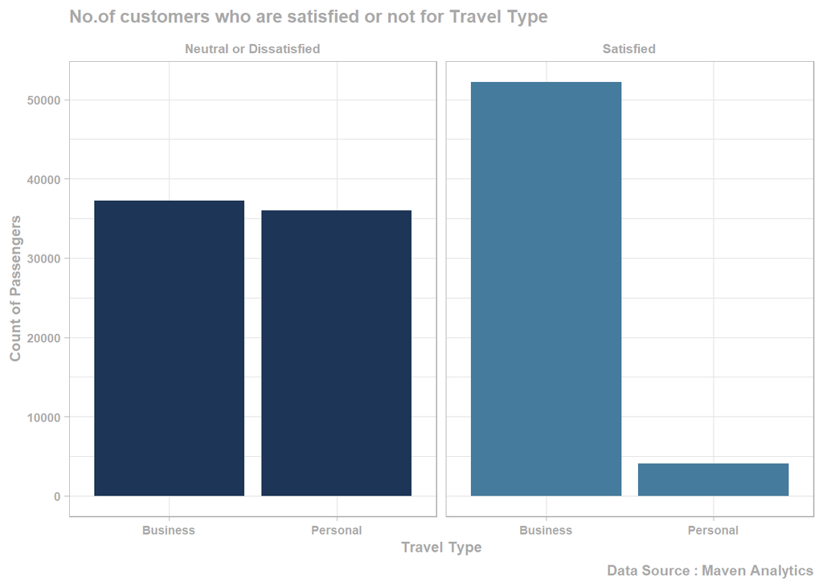

```r
passenger_df %>%
  ggplot(aes(type_of_travel, fill = satisfaction)) +
  geom_bar(show.legend = FALSE) +
  scale_fill_manual(values = c("#1d3557", "#457b9d")) +
  theme_light() +
  theme(axis.title.x = element_text(face = "bold",size = 9, color = "darkgrey"),
        axis.text.x = element_text(face = "bold", size = 7, color = "darkgrey"),
        axis.title.y = element_text(face = "bold",size = 9, color = "darkgrey"),
        axis.text.y = element_text(face = "bold", size = 7, color = "darkgrey"),
        plot.title = element_text(color = "darkgrey", face = "bold", size = 11),
        plot.caption = element_text(color = "darkgrey", face = "bold"),
        strip.text.x = element_text(face = "bold", size = 8, color = "darkgrey"),
        strip.background = element_rect(fill = "white")) +
  facet_wrap(vars(satisfaction)) +
  labs(x = "Travel Type",
       y = "Count of Passengers",
       title = "No.of customers who are satisfied or not for Travel Type",
       caption = "Data Source : Maven Analytics")
```

Personal travelers are about 31% but 90% from these are dis-satisfied.

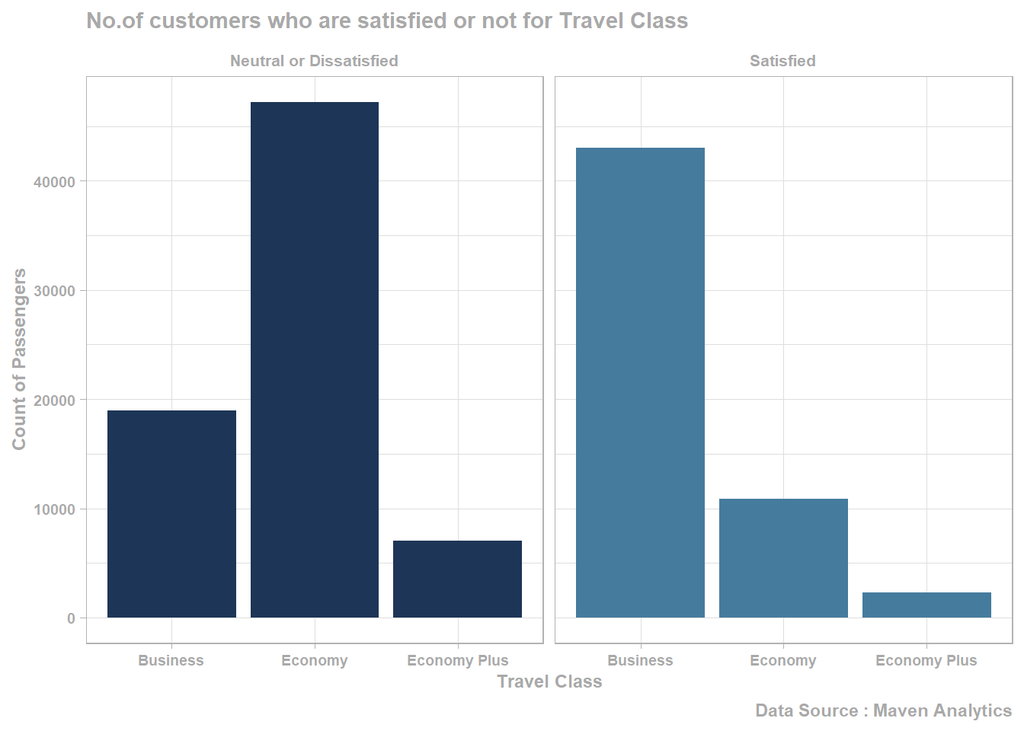

```r
passenger_df %>%
  ggplot(aes(class, fill = satisfaction)) +
  geom_bar(show.legend = FALSE) +
  scale_fill_manual(values = c("#1d3557", "#457b9d")) +
  theme_light() +
  theme(axis.title.x = element_text(face = "bold",size = 9, color = "darkgrey"),
        axis.text.x = element_text(face = "bold", size = 7, color = "darkgrey"),
        axis.title.y = element_text(face = "bold",size = 9, color = "darkgrey"),
        axis.text.y = element_text(face = "bold", size = 7, color = "darkgrey"),
        plot.title = element_text(color = "darkgrey", face = "bold", size = 11),
        plot.caption = element_text(color = "darkgrey", face = "bold"),
        strip.text.x = element_text(face = "bold", size = 8, color = "darkgrey"),
        strip.background = element_rect(fill = "white")) +
  facet_wrap(vars(satisfaction)) +
  labs(x = "Travel Class",
       y = "Count of Passengers",
       title = "No.of customers who are satisfied or not for Travel Class",
       caption = "Data Source : Maven Analytics")
```

Business class is doing good with almost 70% satisfied customers.  
Economy is having worst customer experience as they count for 45% of total passengers and more than 80% are dis-satisfied.  
Economy Plus have lowest count of customers but there 75% customers are also dis-satisfied.